# Cómo crear mapas en R (aplicable a cualquier país)

Author

Camila Castro Pinto

Published

Invalid Date

## 1 Introducción

Se utiliza un **mapa bivariado**, una técnica que permite representar dos variables simultáneamente mediante una paleta de color 2D. Esto revela patrones que un mapa tradicional no podría mostrar: qué departamentos concentran ambos problemas al mismo tiempo.

## 2 Preparación del entorno

**Ver código**

```r
# Obligatorias
library(sf)        # manejo de datos geoespaciales
library(ggplot2)   # visualización
library(dplyr)     # manipulación de datos

# Para el shapefile
library(geodata)   # descarga automática del shapefile de Perú (o de otro país)

# Para unir mapa + leyenda
library(cowplot)
```

## 3 Obtención del mapa base

En este caso se pueden usar 2 opciones, descargar el shapefile de una fuente OFICIAL que contiene una mayor precisión, o usar la de la librería geodata, para fines prácticos se trabaja con la librería cargada pero se muestra que hacer cuando se importa el shapefile.

**Ver código**

```r
# Opción 1: descarga automática con geodata (recomendada, no requiere archivos externos)
peru_sf <- gadm(country = "PER", level = 1, path = tempdir()) |>
st_as_sf()

# Opción 2: shapefile oficial del IGN/INEI (mayor precisión cartográfica)
# Reemplaza la ruta con donde guardaste tu archivo

# peru_sf <- st_read("DEPARTAMENTO.gpkg")
# Ver las capas disponibles dentro del gpkg (puede tener varias)
# st_layers("DEPARTAMENTO.gpkg")


# Verificamos los nombres exactos de los departamentos
# (importante para que el join no falle)
names(peru_sf) # Ver como se llama la variable de nombres
```

```
 [1] "GID_1"     "GID_0"     "COUNTRY"   "NAME_1"    "VARNAME_1" "NL_NAME_1"
 [7] "TYPE_1"    "ENGTYPE_1" "CC_1"      "HASC_1"    "ISO_1"     "geometry"
```

**Ver código**

```r
peru_sf$NAME_1 # Ver los nombres de los departamentos en el paquete
```

```
 [1] "Amazonas"      "Ancash"        "Apurímac"      "Arequipa"
 [5] "Ayacucho"      "Cajamarca"     "Callao"        "Cusco"
 [9] "Huancavelica"  "Huánuco"       "Ica"           "Junín"
[13] "La Libertad"   "Lambayeque"    "Lima"          "Lima Province"
[17] "Loreto"        "Madre de Dios" "Moquegua"      "Pasco"
[21] "Piura"         "Puno"          "San Martín"    "Tacna"
[25] "Tumbes"        "Ucayali"
```

En este caso, se recodifica Lima Province como Lima Metropolitana y Lima como Departamento de Lima, siguiendo la forma en que la fuente reporta los datos.

**Ver código**

```r
peru_sf <- peru_sf |>
  mutate(
    region = toupper(trimws(NAME_1)),
    region = case_when(
      region == "LIMA PROVINCE" ~ "LIMA METROPOLITANA",
      region == "LIMA" ~ "DEPARTAMENTO DE LIMA",
      TRUE ~ region
    )
  )

# Verificación
peru_sf$region
```

```
 [1] "AMAZONAS"             "ANCASH"               "APURÍMAC"
 [4] "AREQUIPA"             "AYACUCHO"             "CAJAMARCA"
 [7] "CALLAO"               "CUSCO"                "HUANCAVELICA"
[10] "HUÁNUCO"              "ICA"                  "JUNÍN"
[13] "LA LIBERTAD"          "LAMBAYEQUE"           "DEPARTAMENTO DE LIMA"
[16] "LIMA METROPOLITANA"   "LORETO"               "MADRE DE DIOS"
[19] "MOQUEGUA"             "PASCO"                "PIURA"
[22] "PUNO"                 "SAN MARTÍN"           "TACNA"
[25] "TUMBES"               "UCAYALI"
```

## 4 Preparación de los datos

**Ver código**

```r
# Fuente anemia      : ENDES 2024 — INEI
# Fuente desnutrición: INEI 2024
# Anemia             : proporción original × 100 para obtener porcentaje
# Criterio usado     : Anemia 6–35 meses /4
# Nota desnutrición  : valores entre paréntesis en la fuente original indican
#                      alta variabilidad muestral; se usan con precaución.

datos <- data.frame(
  region = c(
    "AMAZONAS", "ANCASH", "APURÍMAC", "AREQUIPA", "AYACUCHO",
    "CAJAMARCA", "CALLAO", "CUSCO", "HUANCAVELICA", "HUÁNUCO",
    "ICA", "JUNÍN", "LA LIBERTAD", "LAMBAYEQUE",
    "DEPARTAMENTO DE LIMA", "LIMA METROPOLITANA"  ,
    "LORETO", "MADRE DE DIOS", "MOQUEGUA", "PASCO", "PIURA",
    "PUNO", "SAN MARTÍN", "TACNA", "TUMBES", "UCAYALI"
  ),

  anemia = c(
    46.4, 37.5, 43.0, 43.9, 45.7,
    40.6, 24.5, 45.3, 32.9, 41.7,
    31.1, 41.2, 25.6, 25.9,
    30.3, 24.0,
    50.9, 45.5, 38.6, 36.2, 35.4,
    53.1, 34.6, 32.9, 34.6, 42.8
  ),

  desnutricion = c(
    20.4, 13.5, 15.7, 5.6, 17.0,
    20.4, 6.2, 12.1, 24.0, 16.5,
    7.6, 17.8, 16.8, 13.1,
    6.3, 4.3,
    19.5, 8.4, 2.7, 14.1, 14.3,
    11.5, 10.0, 2.9, 10.4, 19.4
  )
)
```

### 4.1 Validación de datos antes del join

**Ver código**

```r
# Limpieza básica de nombres
datos <- datos |>
  mutate(
    region = toupper(trimws(region))
  )

# Verificar que todas las columnas tengan 26 valores
nrow(datos)
```

```
[1] 26
```

**Ver código**

```r
# Verificar coincidencias entre shapefile y datos
setdiff(datos$region, peru_sf$region)
```

```
character(0)
```

**Ver código**

```r
setdiff(peru_sf$region, datos$region)
```

```
character(0)
```

## 5 Unión entre datos y geometría

**Ver código**

```r
peru_datos <- peru_sf |>
  left_join(datos, by = "region")

# Verificación final: si da 0, el join fue perfecto
sum(is.na(peru_datos$anemia))
```

```
[1] 0
```

**Ver código**

```r
sum(is.na(peru_datos$desnutricion))
```

```
[1] 0
```

## 6 Mapa coroplético de anemia

**Ver código**

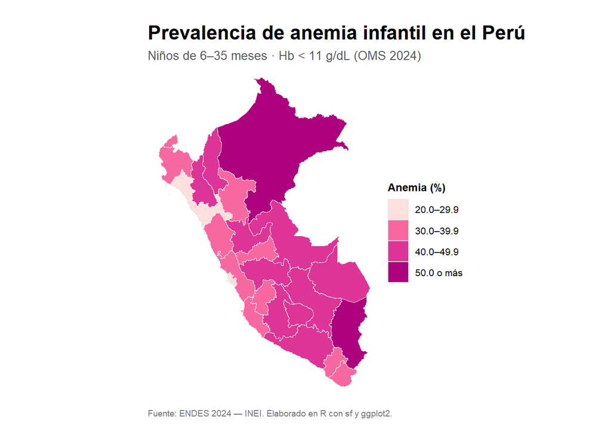

```r
# Clasificación en categorías
peru_datos <- peru_datos |>
  mutate(
    anemia_cat = cut(
      anemia,
      breaks = c(0, 29.9, 39.9, 49.9, 60),
      labels = c("20.0–29.9", "30.0–39.9", "40.0–49.9", "50.0 o más"),
      include.lowest = TRUE
    )
  )

# Mapa
mapa_anemia <- ggplot(peru_datos) +
  geom_sf(
    aes(fill = anemia_cat),
    color = "grey90",      # bordes suaves
    linewidth = 0.2
  ) +
  scale_fill_manual(
    values = c(
      "20.0–29.9" = "#fde0dd",
      "30.0–39.9" = "#f768a1",
      "40.0–49.9" = "#dd3497",
      "50.0 o más" = "#ae017e"
    ),
    name = "Anemia (%)"
  ) +
  labs(
    title = "Prevalencia de anemia infantil en el Perú",
    subtitle = "Niños de 6–35 meses · Hb < 11 g/dL (OMS 2024)",
    caption = "Fuente: ENDES 2024 — INEI. Elaborado en R con sf y ggplot2."
  ) +
  theme_void() +
  theme(
    plot.title = element_text(size = 16, face = "bold", hjust = 0),
    plot.subtitle = element_text(size = 10, hjust = 0, color = "grey35"),
    plot.caption = element_text(size = 7, hjust = 0, color = "grey45"),
    legend.position = "right",
    legend.title = element_text(size = 9, face = "bold"),
    legend.text = element_text(size = 8),
    plot.margin = margin(15, 20, 15, 20),
    plot.background = element_rect(fill = "white", color = NA)
  )

mapa_anemia
```

## 7 Mapa bivariado: anemia y desnutrición crónica

### 7.1 Categorización bivariada

Se utilizan terciles (ntile) en lugar de cortes OMS absolutos porque la variabilidad interna de Perú no se discrimina adecuadamente con umbrales diseñados para comparación internacional. Fuente cortes OMS como referencia: WHO (2001), WHO/UNICEF (2012)

**Ver código**

```r
peru_datos <- peru_datos |>
  mutate(
    cat_anemia       = ntile(anemia, 3),
    cat_desnutricion = ntile(desnutricion, 3),
    bivar_class      = as.character(paste0(cat_anemia, "-", cat_desnutricion))
  )

table(peru_datos$bivar_class)
```

```
1-1 1-2 1-3 2-1 2-2 2-3 3-1 3-2 3-3
  6   1   2   1   5   3   2   3   3
```

### 7.2 Paleta de colores bivariada

**Ver código**

```r
# Eje X (→) = Anemia       : tonos azules
# Eje Y (↑) = Desnutrición : tonos púrpura/rosados
# Cruce de ambos altos      : azul oscuro (más crítico)
# Esta paleta es estándar en cartografía bivariada académica

paleta_bivar <- c(
  "1-1" = "#f3f3f3",  # leve    + baja   → casi blanco
  "2-1" = "#d4e6f7",  # moderada + baja  → azul muy claro
  "3-1" = "#a8cfe8",  # grave   + baja   → azul claro
  "1-2" = "#f7d4e6",  # leve    + media  → rosa muy claro
  "2-2" = "#c9b8d8",  # moderada + media → lila
  "3-2" = "#7b9fd4",  # grave   + media  → azul medio
  "1-3" = "#e8a0c8",  # leve    + alta   → rosa
  "2-3" = "#b07cc0",  # moderada + alta  → púrpura
  "3-3" = "#3d0066"   # grave   + alta   → púrpura oscuro CRÍTICO
)
```

### 7.3 Mapa principal

**Ver código**

```r
mapa <- ggplot(peru_datos) +

  geom_sf(
    aes(fill = bivar_class),
    color     = "grey90",   # ← antes white (muy fuerte)
    linewidth = 0.2         # ← más fino
  ) +

  scale_fill_manual(values = paleta_bivar) +

  labs(
    title    = "Anemia y desnutrición crónica infantil en el Perú",
    subtitle = "Niños de 6–35 meses · Hb < 11 g/dL (OMS 2024)",
    caption  = "Fuente: ENDES 2024 — INEI. Elaborado en R (sf + ggplot2)"
  ) +

  theme_void() +
  theme(
    plot.title = element_text(
      size   = 16,
      face   = "bold",
      hjust  = 0   # ← izquierda (pro)
    ),
    plot.subtitle = element_text(
      size   = 10,
      hjust  = 0,
      color  = "grey35"
    ),
    plot.caption = element_text(
      size   = 7,
      hjust  = 0,
      color  = "grey45"
    ),
    legend.position = "none",
    plot.background = element_rect(fill = "white", color = NA),
    plot.margin     = margin(15, 20, 15, 20)
  )
```

### 7.4 Leyenda bivariada

**Ver código**

```r
# Ver los puntos de corte reales de ntile
quantile(peru_datos$anemia, probs = c(0, 1/3, 2/3, 1), na.rm = TRUE)
```

```
       0% 33.33333% 66.66667%      100%
 24.00000  34.60000  42.43333  53.10000
```

**Ver código**

```r
quantile(peru_datos$desnutricion, probs = c(0, 1/3, 2/3, 1), na.rm = TRUE)
```

```
       0% 33.33333% 66.66667%      100%
  2.70000  10.13333  16.23333  24.00000
```

**Ver código**

```r
combinaciones_reales <- unique(peru_datos$bivar_class)

leyenda_df <- expand.grid(
  anemia       = 1:3,
  desnutricion = 1:3
) |>
  mutate(
    bivar_class = paste0(anemia, "-", desnutricion),
    existe      = bivar_class %in% combinaciones_reales
  )

leyenda <- ggplot(leyenda_df) +
  geom_tile(
    aes(x = anemia, y = desnutricion, fill = bivar_class, alpha = existe),
    color     = "white",
    linewidth = 0.6
  ) +
  scale_fill_manual(values = paleta_bivar) +
  scale_alpha_manual(values = c("TRUE" = 1, "FALSE" = 0.15)) +
 scale_x_continuous(
  breaks = c(1, 2, 3),
  labels = c("Bajo\n(24–34.6)", "Medio\n(34.6–42.4)", "Alto\n(42.4–53.1)"),
  expand = c(0, 0)
) +
scale_y_continuous(
  breaks = c(1, 2, 3),
  labels = c("Baja\n(2.7–10.1)", "Media\n(10.1–16.2)", "Alta\n(16.2–24.0)"),
  expand = c(0, 0)
) +
  labs(x = "Anemia (%)", y = "Desnutrición\ncrónica (%) ") +
  coord_fixed() +
  theme_void() +
  theme(
    legend.position = "none",
    axis.text.x     = element_text(size = 6, color = "grey30"),
    axis.text.y     = element_text(size = 6, color = "grey30"),
    axis.title.x    = element_text(size = 8, face = "bold",
                                   color = "grey20", margin = margin(t = 4)),
    axis.title.y    = element_text(size = 8, face = "bold",
                                   color = "grey20", angle = 90,
                                   margin = margin(r = 4)),
    plot.background = element_rect(fill = "white", color = NA),
    plot.margin     = margin(2, 2, 2, 2)
  )
```

### 7.5 Mapa final

**Ver código**

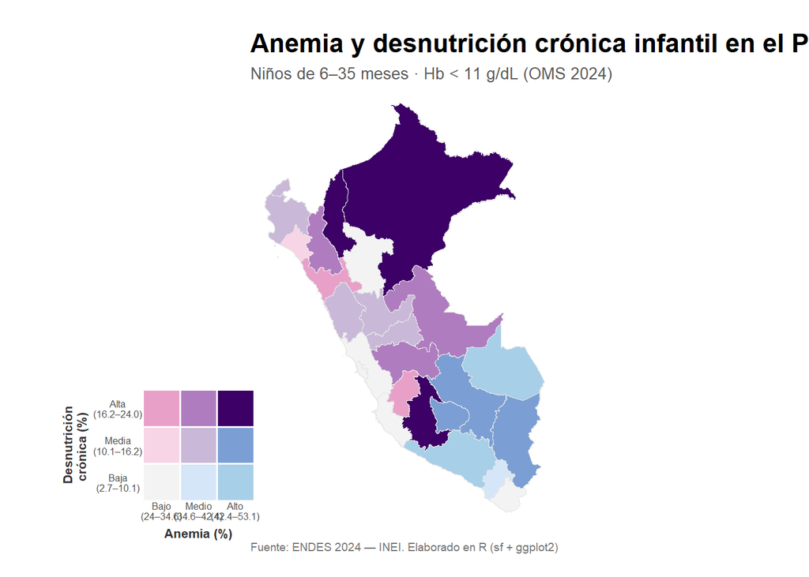

```r
mapa_final <- ggdraw() +
  draw_plot(
    mapa,
    x = 0,
    y = 0,
    width = 1,
    height = 1
  ) +
  draw_plot(
    leyenda,
    x = 0.06,
    y = 0.06,
    width = 0.27,
    height = 0.27
  )

mapa_final
```

**Ver código**

```r
ggsave(
  filename = "mapa_bivariado_anemia_desnutricion_peru_2024.png",
  plot = mapa_final,
  width = 8,
  height = 10,
  dpi = 300,
  bg = "white"
)
```

## 8 Hallazgos

**Ver código**

```r
resumen <- peru_datos |>
  st_drop_geometry() |>
  mutate(
    criticidad = case_when(
      bivar_class == "3-3"                            ~ "🔴 Crítico (ambas altas)",
      cat_anemia == 3 | cat_desnutricion == 3         ~ "🟠 Alto en al menos una",
      cat_anemia == 1 & cat_desnutricion == 1         ~ "🟢 Bajo en ambas",
      TRUE                                            ~ "🟡 Moderado"
    )
  ) |>
  arrange(desc(anemia)) |>
  select(
    Departamento       = region,
    `Anemia (%)`       = anemia,
    `Desnutrición (%)` = desnutricion,
    Clasificación      = criticidad
  )

knitr::kable(resumen, align = c("l", "r", "r", "l"))
```

| Departamento | Anemia (%) | Desnutrición (%) | Clasificación |
| --- | --- | --- | --- |
| PUNO | 53.1 | 11.5 | 🟠 Alto en al menos una |
| LORETO | 50.9 | 19.5 | 🔴 Crítico (ambas altas) |
| AMAZONAS | 46.4 | 20.4 | 🔴 Crítico (ambas altas) |
| AYACUCHO | 45.7 | 17.0 | 🔴 Crítico (ambas altas) |
| MADRE DE DIOS | 45.5 | 8.4 | 🟠 Alto en al menos una |
| CUSCO | 45.3 | 12.1 | 🟠 Alto en al menos una |
| AREQUIPA | 43.9 | 5.6 | 🟠 Alto en al menos una |
| APURÍMAC | 43.0 | 15.7 | 🟠 Alto en al menos una |
| UCAYALI | 42.8 | 19.4 | 🟠 Alto en al menos una |
| HUÁNUCO | 41.7 | 16.5 | 🟡 Moderado |
| JUNÍN | 41.2 | 17.8 | 🟠 Alto en al menos una |
| CAJAMARCA | 40.6 | 20.4 | 🟠 Alto en al menos una |
| MOQUEGUA | 38.6 | 2.7 | 🟡 Moderado |
| ANCASH | 37.5 | 13.5 | 🟡 Moderado |
| PASCO | 36.2 | 14.1 | 🟡 Moderado |
| PIURA | 35.4 | 14.3 | 🟡 Moderado |
| SAN MARTÍN | 34.6 | 10.0 | 🟢 Bajo en ambas |
| TUMBES | 34.6 | 10.4 | 🟡 Moderado |
| HUANCAVELICA | 32.9 | 24.0 | 🟠 Alto en al menos una |
| TACNA | 32.9 | 2.9 | 🟢 Bajo en ambas |
| ICA | 31.1 | 7.6 | 🟢 Bajo en ambas |
| DEPARTAMENTO DE LIMA | 30.3 | 6.3 | 🟢 Bajo en ambas |
| LAMBAYEQUE | 25.9 | 13.1 | 🟡 Moderado |
| LA LIBERTAD | 25.6 | 16.8 | 🟠 Alto en al menos una |
| CALLAO | 24.5 | 6.2 | 🟢 Bajo en ambas |
| LIMA METROPOLITANA | 24.0 | 4.3 | 🟢 Bajo en ambas |

## 9 Interpretación

El mapa bivariado evidencia una heterogeneidad espacial en la distribución de la anemia y la desnutrición crónica infantil en el Perú.

Asimismo, se identifican regiones donde existe discordancia entre ambas variables, es decir, departamentos con alta anemia pero menor desnutrición o viceversa. Esto sugiere que, aunque relacionadas, ambas condiciones responden a determinantes distintos y no necesariamente evolucionan de manera paralela.

En conjunto, el mapa permite visualizar patrones territoriales que no serían evidentes mediante análisis univariados, destacando la utilidad del enfoque bivariado para la identificación de áreas prioritarias de intervención.

## 10 Limitaciones

El presente análisis presenta varias limitaciones que deben ser consideradas al interpretar los resultados.

En primer lugar, la categorización de las variables en terciles corresponde a una clasificación relativa dentro del conjunto de departamentos analizados, por lo que las categorías de “bajo”, “medio” y “alto” no representan puntos de corte clínicos establecidos, sino posiciones relativas en la distribución.

En segundo lugar, los indicadores de anemia y desnutrición corresponden a diferentes definiciones operativas y grupos etarios específicos, lo cual puede limitar la comparabilidad directa entre ambas variables.

Asimismo, el análisis se realiza a nivel departamental, lo que puede ocultar heterogeneidad interna significativa dentro de cada región (problema de agregación espacial o efecto ecológico).

Finalmente, el mapa bivariado, aunque útil para explorar patrones conjuntos, no permite establecer relaciones causales entre las variables, por lo que los resultados deben interpretarse como descriptivos y exploratorios.